# Covid Trash Models

To model Florida cases we start with a base model. We can see that the most favored model by BIC is an AR(1). So we begin by building that model. Our AR(1) has a phi of .975, quite close to the unit circle, which we expect to model strongly wandering behavior.

This model has an AIC estimate of 14.01.

In order to estimate an average ASE, we are running this model over segments of our data with 54 iterations. In each case training with at least seventy data points and predicting on twelve. Overall this produces an average ASE of 6,353,070.

```r
aic5.wge(newcases_fl$positiveIncrease, type = 'bic')


fl_ar_1 = est.ar.wge(newcases_fl$positiveIncrease, p = 1)

fl_ar_1$aic

trainingSize = 70
horizon = 12
ASEHolder = numeric()

for( i in 1:(135-(trainingSize + horizon) + 1))
{

  forecasts = fore.aruma.wge(newcases_fl$positiveIncrease[i:(i+(trainingSize-1))],phi = fl_ar_1$phi, n.ahead = horizon, plot = FALSE)

  ASE = mean((newcases_fl$positiveIncrease[(trainingSize+i):(trainingSize+ i + (horizon) - 1)] - forecasts$f)^2)
  ASEHolder[i] = ASE

}

ASEHolder
#Distribution of ASEs on Two Week Periods
hist(ASEHolder, xlab = "ASE of model at a given Training Set",  main = "ASE Distribution for Model ARIMA(2,1,1) for Florida Data")

#Mean ASE
WindowedASE = mean(ASEHolder)
WindowedASE


short_fl_ar1 = fore.aruma.wge(newcases_us$positiveIncrease,phi = fl_ar_1$phi, n.ahead = 7, plot = TRUE)

long_us_ar1 = fore.aruma.wge(newcases_us$positiveIncrease,phi = fl_ar_1$phi, n.ahead = 90, plot = TRUE)
```

[output not shown]

###US Model One - AR 1

```r
aic5.wge(newcases_us$positiveIncrease)
aic5.wge(newcases_us$positiveIncrease, type = 'bic')


us_ar_1 = est.ar.wge(newcases_us$positiveIncrease, p = 1)
us_ar_1
us_ar_1$aic

trainingSize = 70
horizon = 12
ASEHolder = numeric()

for( i in 1:(177-(trainingSize + horizon) + 1))
{

  forecasts = fore.aruma.wge(newcases_us$positiveIncrease[i:(i+(trainingSize-1))],phi = us_ar_1$phi, n.ahead = horizon, plot = FALSE)

  ASE = mean((newcases_us$positiveIncrease[(trainingSize+i):(trainingSize+ i + (horizon) - 1)] - forecasts$f)^2)
  ASEHolder[i] = ASE

}

ASEHolder
#Distribution of ASEs on Two Week Periods
hist(ASEHolder, xlab = "ASE of model at a given Training Set",  main = "ASE Distribution for Model ARIMA(2,1,1) for Florida Data")

#Mean ASE
WindowedASE = mean(ASEHolder)
WindowedASE


short_fl_ar1 = fore.aruma.wge(newcases_us$positiveIncrease,phi = us_ar_1$phi, n.ahead = 7, plot = TRUE)

long_us_ar1 = fore.aruma.wge(newcases_us$positiveIncrease,phi = us_ar_1$phi, n.ahead = 90, plot = TRUE)
```

[output not shown]

####Florida ARIMA Model

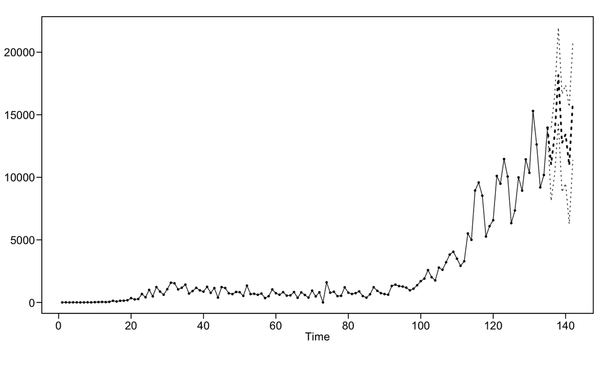

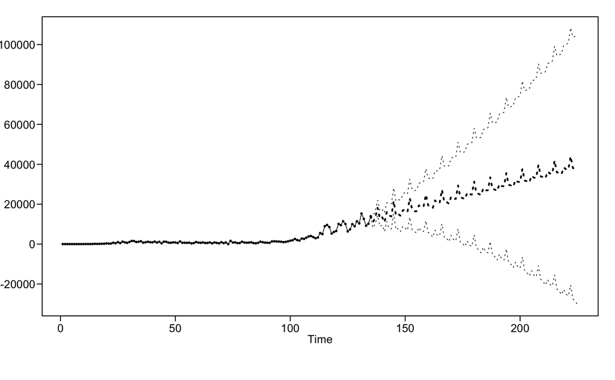

```r
short_fl_ar1 = fore.aruma.wge(newcases_fl$positiveIncrease,phi = model_arima$coef[1:2], s = 7, d = 1, n.ahead = 7, plot = TRUE)

long_fl_ar1 = fore.aruma.wge(newcases_fl$positiveIncrease,phi = model_arima$coef[1:2], s = 7, d = 1,  n.ahead = 90, plot = TRUE)
```

VAR/MLR with Correlated Errors Model

```r
library(vars)
VARselect(newcases_fl_multi,lag.max = 10, type = "both")
#AIC of 25.76087

cases_fl_VAR = VAR(newcases_fl_multi,type = "trend",p = 4)
preds=predict(cases_fl_VAR,n.ahead=12)
plot(preds)



ASE = mean((newcases_fl_multi$positiveIncrease[123:135] - preds$fcst$positiveIncrease)^2)
ASE
#35935880
```

[output not shown]

#### Florida Cases - ARMA Model

```r
fl_arma_21 = est.arma.wge(newcases_fl$positiveIncrease, p = 2, q = 1)

fl_arma_21$aic

trainingSize = 70
horizon = 12
ASEHolder = numeric()

for( i in 1:(135-(trainingSize + horizon) + 1))
{

  forecasts = fore.aruma.wge(newcases_fl$positiveIncrease[i:(i+(trainingSize-1))],phi = fl_arma_21$phi, theta = fl_arma_21$theta, n.ahead = horizon, plot = FALSE)

  ASE = mean((newcases_fl$positiveIncrease[(trainingSize+i):(trainingSize+ i + (horizon) - 1)] - forecasts$f)^2)
  ASEHolder[i] = ASE

}

ASEHolder
#Distribution of ASEs on Two Week Periods
hist(ASEHolder, xlab = "ASE of model at a given Training Set",  main = "ASE Distribution for Model ARIMA(2,1,1) for Florida Data")

#Mean ASE
WindowedASE = mean(ASEHolder)
WindowedASE
##6154656



short_fl_arma = fore.aruma.wge(newcases_fl$positiveIncrease,phi = fl_arma_21$phi,theta = fl_arma_21$theta, n.ahead = 7, plot = TRUE)

long_fl_arma = fore.aruma.wge(newcases_fl$positiveIncrease,phi = fl_arma_21$phi,theta = fl_arma_21$theta, n.ahead = 90, plot = TRUE)

final_pred = fore.aruma.wge(newcases_fl$positiveIncrease[1:123],phi = fl_arma_21$phi,theta = fl_arma_21$theta, n.ahead = 12, plot = TRUE)
final_pred_df = data.frame(t = seq(124:135), final_pred$f)

plot(newcases_fl$positiveIncrease, type = "l", ylab = "Count of New Cases", xlab = "Time", main = "Florida ARMA(2,1) Model Final 12 Predictions")
lines(ts(final_pred$f, start = 124, end = 135),  col = "blue")

final_ASE = mean((newcases_fl$positiveIncrease[124:135] - final_pred$f)^2)
final_ASE
```

[output not shown]

####US Cases ARMA(1,2)

```r
us_arma_12 = est.arma.wge(newcases_us$positiveIncrease, p = 1, q = 2)
us_arma_12
us_arma_12$aic

trainingSize = 70
horizon = 12
ASEHolder = numeric()

for( i in 1:(177-(trainingSize + horizon) + 1))
{

  forecasts = fore.aruma.wge(newcases_us$positiveIncrease[i:(i+(trainingSize-1))],phi = us_arma_12$phi, theta = us_arma_12$theta, n.ahead = horizon, plot = FALSE)

  ASE = mean((newcases_us$positiveIncrease[(trainingSize+i):(trainingSize+ i + (horizon) - 1)] - forecasts$f)^2)
  ASEHolder[i] = ASE

}

ASEHolder
#Distribution of ASEs on Two Week Periods
hist(ASEHolder, xlab = "ASE of model at a given Training Set",  main = "ASE Distribution for Model ARIMA(2,1,1) for Florida Data")

#Mean ASE
WindowedASE = mean(ASEHolder)
WindowedASE
#55171440


short_us_ar1 = fore.aruma.wge(newcases_us$positiveIncrease,phi = us_arma_12$phi,theta = us_arma_12$theta, n.ahead = 7, plot = TRUE)

long_us_ar1 = fore.aruma.wge(newcases_us$positiveIncrease,phi = us_arma_12$phi,theta = us_arma_12$theta, n.ahead = 90, plot = TRUE)



final_pred = fore.aruma.wge(newcases_us$positiveIncrease[1:165],phi = us_arma_12$phi,theta = us_arma_12$theta, n.ahead = 12, plot = TRUE)
final_pred_df = data.frame(t = seq(166:177), final_pred$f)

plot(newcases_us$positiveIncrease, type = "l", ylab = "Count of New Cases", xlab = "Time", main = "United States ARMA(1,2) Model Final 12 Predictions")
lines(ts(final_pred$f, start = 166, end = 177),  col = "blue")
```

[output not shown]